# Exploración de los datos y Preprocesamiento

Roberto Saborit Roig

22/3/2021

# Dataset

Lo primero es ver que dataset vamos a utilizar, disponemos de dos conjuntos de datos para realizar el estudio, uno es una cohorte de datos longitudinal, mientras que el otro que tenemos en uno seccional. EStos conjuntos pertenecen al proyecto OASIS, que es un proyecto que pretende poner a libre disposición datos de estudios realizados en MRI. Iremos realizando el preprocesamiento en ambos conjuntos de manera paralela. Y dispondremos de los dos conjuntos para generar el modelo, probablemente utilizaremos uno como conjunto de de entrenamiento y otro para el test. Pero eso lo valoraremos más adelante en función de los resultados que obtengamos en la exploración de los datos y el preprocesamiento.

```r
#Lo primero será cargar los datos y guardarlos en ls dataframes oasis_longitudinal y oasis_cross_seccional.
oasis_cross_sectional <- read.csv("oasis_cross-sectional.csv")
oasis_longitudinal <- readxl::read_excel("oasis_longitudinal_demographics.xlsx")
```

# Exploración de los datos

Antes de comezar a generar el modelo, incluso antes del preprocesamiento, vamos a realizar una exploración de los datos con los siguientes objetivos:

- Ver si existen valores ausentes en el conjunto de datos y ver su distribución entre las distintas variables.
- Explorar los tipos de variable y ver si necesitamos cambiar la clase de alguna variable.
- Ver la distribución de las variables, tanto de la respuesta como de las variables descriptivas.

## Tipos de variables

La primera comprobación que haremos será ver los tipos de variables que hay y si todas tienen el tipo de valor que le corresponde:

```r
#Exploramos las variables, sus tipos y vemos si es necesario cambiar algún tipo para posteriores análisis
str(oasis_cross_sectional)
```

```
## 'data.frame':    436 obs. of  12 variables:
##  $ ID   : chr  "OAS1_0001_MR1" "OAS1_0002_MR1" "OAS1_0003_MR1" "OAS1_0004_MR1" ...
##  $ M.F  : chr  "F" "F" "F" "M" ...
##  $ Hand : chr  "R" "R" "R" "R" ...
##  $ Age  : int  74 55 73 28 18 24 21 20 74 52 ...
##  $ Educ : int  2 4 4 NA NA NA NA NA 5 3 ...
##  $ SES  : int  3 1 3 NA NA NA NA NA 2 2 ...
##  $ MMSE : int  29 29 27 NA NA NA NA NA 30 30 ...
##  $ CDR  : num  0 0 0.5 NA NA NA NA NA 0 0 ...
##  $ eTIV : int  1344 1147 1454 1588 1737 1131 1516 1505 1636 1321 ...
##  $ nWBV : num  0.743 0.81 0.708 0.803 0.848 0.862 0.83 0.843 0.689 0.827 ...
##  $ ASF  : num  1.31 1.53 1.21 1.1 1.01 ...
##  $ Delay: chr  "N/A" "N/A" "N/A" "N/A" ...
```

```r
str(oasis_longitudinal)
```

```
## tibble [373 x 15] (S3: tbl_df/tbl/data.frame)
##  $ Subject ID: chr [1:373] "OAS2_0001" "OAS2_0001" "OAS2_0002" "OAS2_0002" ...
##  $ MRI ID    : chr [1:373] "OAS2_0001_MR1" "OAS2_0001_MR2" "OAS2_0002_MR1" "OAS2_0002_MR2" ...
##  $ Group     : chr [1:373] "Nondemented" "Nondemented" "Demented" "Demented" ...
##  $ Visit     : chr [1:373] "1" "2" "1" "2" ...
##  $ MR Delay  : num [1:373] 0 457 0 560 1895 ...
##  $ M/F       : chr [1:373] "M" "M" "M" "M" ...
##  $ Hand      : chr [1:373] "R" "R" "R" "R" ...
##  $ Age       : num [1:373] 87 88 75 76 80 88 90 80 83 85 ...
##  $ EDUC      : num [1:373] 14 14 12 12 12 18 18 12 12 12 ...
##  $ SES       : num [1:373] 2 2 NA NA NA 3 3 4 4 4 ...
##  $ MMSE      : num [1:373] 27 30 23 28 22 28 27 28 29 30 ...
##  $ CDR       : num [1:373] 0 0 0.5 0.5 0.5 0 0 0 0.5 0 ...
##  $ eTIV      : num [1:373] 1987 2004 1678 1738 1698 ...
##  $ nWBV      : num [1:373] 0.696 0.681 0.736 0.713 0.701 ...
##  $ ASF       : num [1:373] 0.883 0.876 1.046 1.01 1.034 ...
```

Lo primero que tenemos que tener en cuenta en ambos conjuntos es que el conjunto longitudinal esta etiquetado por grupos en la variable `Group`, estos son “demented”, “non demented” y “converted”.Hacen referencia a sujetos con demencia, sin demencia y que desarrollaron demencia a lo largo del experimento, repectivamente. En cambio el estudio seccional no tiene estas etiquetas, pero realmente la variable `CDR` (Clasificación Clínica de Demencia), hace referencia a lo mismo, es decir, al nivel de demencia que tienen los pacientes según este test, que va desde 0 (no tiene demencia), 0.5 (demencia muy leve), 1 (demencia leve) o 2 (demencia severa). Podemos abordar el problema simplemente creando la variable `Group` y etiqutando como demented aquellos que tienen un nivel de demencia mayor de 0.

Además vemos que tenemos 2 variables más en el estudio longitudinal que son `visit`que hace referencia al número de visita de esa observación y `MR delay`, que es el tiempo que ha pasado entre visita y visita.

Por otro lado la variable Hand no aporta ninguna información ya que todos los sujetos son diestros, por tanto, la eliminaremos del conjunto:

```r
#La función levels muestra los niveles de la variable $Hand
levels(as.factor(oasis_cross_sectional$Hand))
```

```
## [1] "R"
```

```r
levels(as.factor(oasis_longitudinal$Hand))
```

```
## [1] "R"
```

Como vemos solo existe un nivel en el factor que es “R” (Right/Diestro), por lo que no nos aportará ningún valor al modelo, pero si hay que tener en cuenta que el modelo lo habremos realizado solo en personas diestras y si esta variable tuviera importancia en la aparición de demencia los resultados podrían no ser tan precisos en personas zurdas.

## Datos y valores ausentes

Vamos a comprobar ahora el número de datos que tenemos y la cantidad de valores ausentes que hay:

```r
#El número total de filas nos indica la cantidad de observaciones de cada uno de los datasets
nrow(oasis_cross_sectional); ncol(oasis_cross_sectional)
```

```
## [1] 436
```

```
## [1] 12
```

```r
nrow(oasis_longitudinal); ncol(oasis_longitudinal)
```

```
## [1] 373
```

```
## [1] 15
```

```r
any(is.na(oasis_cross_sectional)); any(is.na(oasis_longitudinal))
```

```
## [1] TRUE
```

```
## [1] TRUE
```

```r
#Tenemos datos ausentes en ambos conjuntos
#Podemos comprobar que variables tienen mayor porcentaje de NA y la cantidad total
apply(is.na(oasis_cross_sectional), 2, sum)
```

```
##    ID   M.F  Hand   Age  Educ   SES  MMSE   CDR  eTIV  nWBV   ASF Delay
##     0     0     0     0   201   220   201   201     0     0     0     0
```

```r
apply(is.na(oasis_longitudinal), 2, sum)
```

```
## Subject ID     MRI ID      Group      Visit   MR Delay        M/F       Hand
##          0          0          0          0          0          0          0
##        Age       EDUC        SES       MMSE        CDR       eTIV       nWBV
##          0          0         19          2          0          0          0
##        ASF
##          0
```

En el caso del estudio seccional tenemos una gran cantidad de datos ausentes en las variables Educ, SES, MMSE, CDR, que suponen casi un 50% de los datos, en esas variables, lo que puede suponer un problema si durante el preprocesamiento optamos por eliminar las observaciones con datos ausentes, ya que prederíamos una gran cantidad de información.

En cambio en el conjunto de datos longitudinal no tenemos apenas datos ausentes, solo unos pocos en la variable SES, que es el estatus socioeconómico, y solo 2 en MMSE (test de deterioro cognitivo).

## Distribución de la variable respuesta

Otra información importante que debemos conocer antes de comenzar con el modelo es la distribución de la variable respuesta, es decir la cantidad de observaciones que hay según los grupos que tenemos en la variable respuesta, en nuestro caso nos interesa conocer como está distribuida la variable `Group` en el estudio longitudinal y la variable `CDR` en el estudio longitudinal. Para ello vamos a generar una tabla con los datos y vamos a verlo también gráficamente:

```r
library(ggplot2)
par(mfrow=c(1,2))

#Generamos las tablas, con datos absolutos y relativos
table(oasis_longitudinal$Group)
```

```
##
##   Converted    Demented Nondemented
##          37         146         190
```

```r
round(prop.table(table(oasis_longitudinal$Group)), 2)
```

```
##
##   Converted    Demented Nondemented
##        0.10        0.39        0.51
```

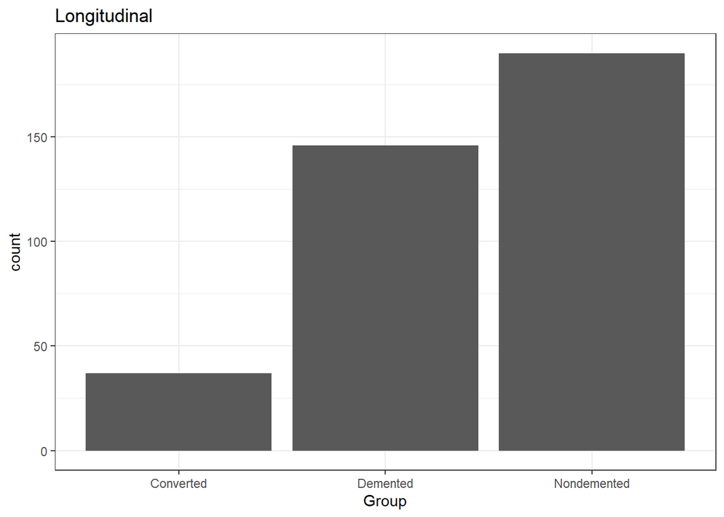

```r
#Y generamos el gráfico
ggplot(data = oasis_longitudinal, aes(x = Group, y = ..count.., )) +
  geom_bar() +
  labs(title = "Longitudinal") +
  theme_bw() +
  theme(legend.position = "bottom")
```

```r
#Hacemos lo mismo con el estudio seccional
table(oasis_cross_sectional$CDR)
```

```
##
##   0 0.5   1   2
## 135  70  28   2
```

```r
round(prop.table(table(oasis_cross_sectional$CDR)), 2)
```

```
##
##    0  0.5    1    2
## 0.57 0.30 0.12 0.01
```

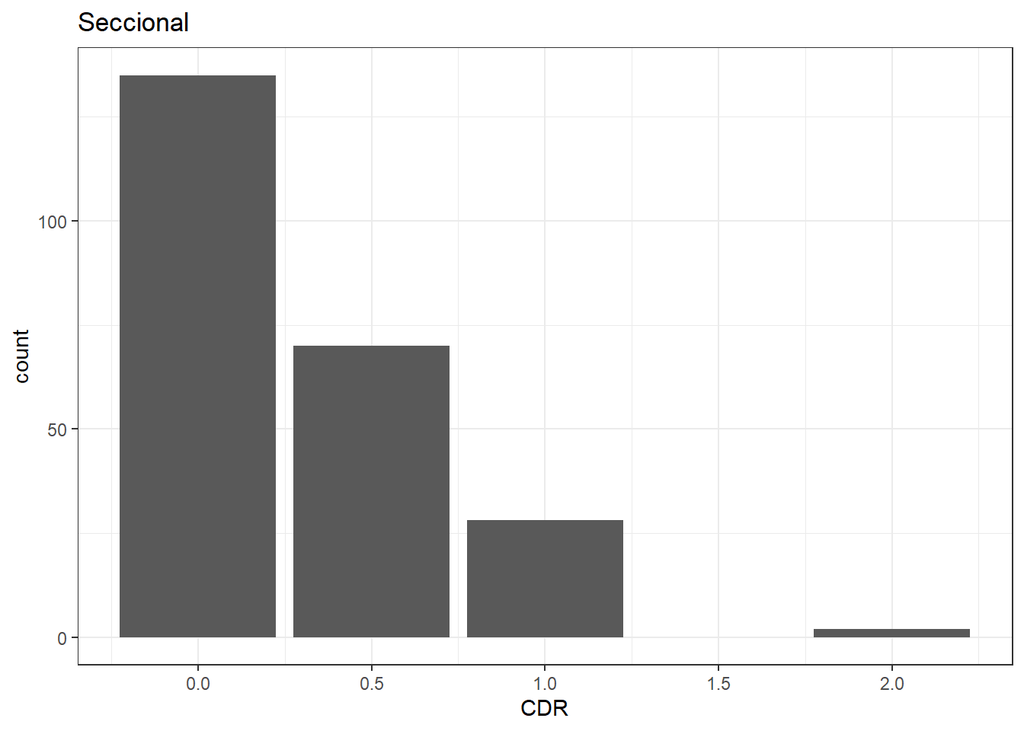

```r
ggplot(data = oasis_cross_sectional, aes(x = CDR, y = ..count.., ),) +
  geom_bar() +
  labs(title = "Seccional") +
  theme_bw() +
  theme(legend.position = "bottom")
```

Como vemos el porcentaje de converted que son aquellos que al principio del experimento no tenían demencia y en las sucesivas medidas la desarrollaron, es del 10% de los datos, estos es importante conocerlo, si desamos crear un modelo efctivo es importante que acierte más del 10% de converted, que podría acertarse si simplemente calsificamos todos los sujetos como converted.

En el caso del estudio seccional lo hemos dividido en grupos según la variable CDR que muestra si se no se tiene demencia, y también vemos una distribución desigual, donde los pacientes con demencia son menos que los que no tienen demencia, sobre todo aquellos que tienen demencia leve y pacientes con demencia moderada apenas hay.

Antes de continuar vamos a eliminar los valores de CDR=2, ya que nos interesa detectar la demencia en estado preclínico (con valores de CDR<2), así que trataremos de comparar personas sin demencia y con demencia en estado muy leve y leve. Des esta forma también nos quitaremos los valores ausentes que haya en nuestra variable respuesta, que no ibamos a poder imputarlos.

```r
library(dplyr)
oasis_cross_sectional_2=filter(oasis_cross_sectional, CDR<2)
```

## Distribución de las variables predictoras

Tras ver la distribución de la variable respuesta, nos interesa conocer la de las variables predictoras

### Variables continuas

```r
library(ggpubr)
```

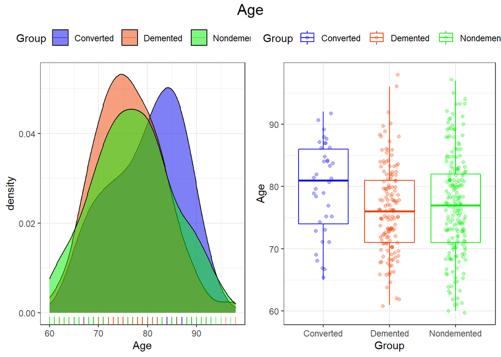

```r
#Creamos un gráfico para ver la distribución de la variable Age
p1 <- ggplot(data = oasis_longitudinal, aes(x = Age, fill = Group)) +
      geom_density(alpha = 0.5) +
      scale_fill_manual(values = c("blue2", "orangered2", "green2")) +
      geom_rug(aes(color = Group), alpha = 0.5) +
      scale_color_manual(values = c("blue2", "orangered2", "green2")) +
      theme_bw()
p2 <- ggplot(data = oasis_longitudinal, aes(x = Group, y = Age, color = Group)) +
      geom_boxplot(outlier.shape = NA) +
      geom_jitter(alpha = 0.3, width = 0.15) +
      scale_color_manual(values = c("blue2", "orangered2", "green2")) +
      theme_bw()
final_plot <- ggarrange(p1, p2, legend = "top")
final_plot <- annotate_figure(final_plot, top = text_grob("Age", size = 15))
final_plot
```

```r
#Calculamos la media y la mediana
tapply(oasis_longitudinal$Age, oasis_longitudinal$Group, mean)
```

```
##   Converted    Demented Nondemented
##    79.75676    76.26027    77.05789
```

```r
tapply(oasis_longitudinal$Age, oasis_longitudinal$Group, median)
```

```
##   Converted    Demented Nondemented
##          81          76          77
```

```r
levels(oasis_cross_sectional$CDR)
```

```r
oasis_cross_sectional_2$Group=factor(oasis_cross_sectional_2$CDR,levels=c(0,0.5,1),
                           labels=c("Nondemented", "Demented", "Demented"))

oasis_cross_sectional_narm=na.omit(oasis_cross_sectional_2)
nrow(oasis_cross_sectional_narm)
```

```
## [1] 214
```

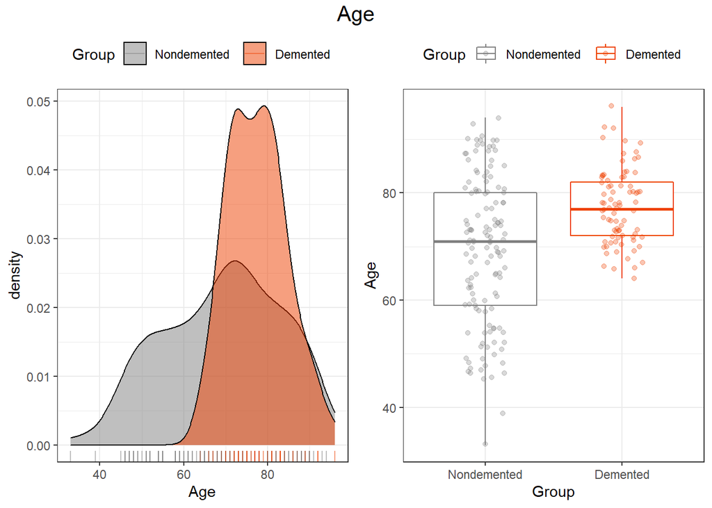

```r
p1 <- ggplot(data = oasis_cross_sectional_narm, aes(x = Age, fill = Group)) +
      geom_density(alpha = 0.5) +
      scale_fill_manual(values = c("gray50", "orangered2")) +
      geom_rug(aes(color = Group), alpha = 0.5) +
      scale_color_manual(values = c("gray50", "orangered2")) +
      theme_bw()
p2 <- ggplot(data = oasis_cross_sectional_narm, aes(x = Group, y = Age, color = Group)) +
      geom_boxplot(outlier.shape = NA) +
      geom_jitter(alpha = 0.3, width = 0.15) +
      scale_color_manual(values = c("gray50", "orangered2")) +
      theme_bw()
final_plot <- ggarrange(p1, p2, legend = "top")
final_plot <- annotate_figure(final_plot, top = text_grob("Age", size = 15))
final_plot
```

```r
#Calculamos la media y la mediana
tapply(oasis_cross_sectional_narm$Age, oasis_cross_sectional_narm$Group, mean)
```

```
## Nondemented    Demented
##    69.23308    77.48148
```

```r
tapply(oasis_cross_sectional_narm$Age, oasis_cross_sectional_narm$Group, median)
```

```
## Nondemented    Demented
##          71          77
```

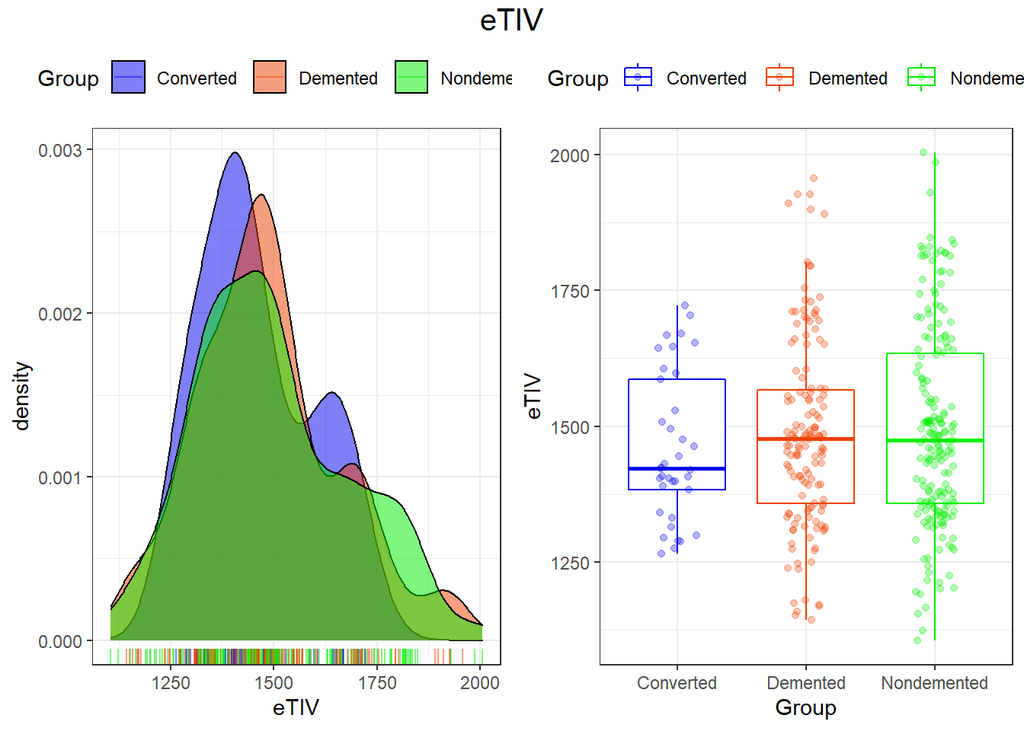

```r
#Volumen intracraneal
p1 <- ggplot(data = oasis_longitudinal, aes(x = eTIV, fill = Group)) +
      geom_density(alpha = 0.5) +
      scale_fill_manual(values = c("blue2", "orangered2", "green2")) +
      geom_rug(aes(color = Group), alpha = 0.5) +
      scale_color_manual(values = c("blue2", "orangered2", "green2")) +
      theme_bw()
p2 <- ggplot(data = oasis_longitudinal, aes(x = Group, y = eTIV, color = Group)) +
      geom_boxplot(outlier.shape = NA) +
      geom_jitter(alpha = 0.3, width = 0.15) +
      scale_color_manual(values = c("blue2", "orangered2", "green2")) +
      theme_bw()
final_plot <- ggarrange(p1, p2, legend = "top")
final_plot <- annotate_figure(final_plot, top = text_grob("eTIV", size = 15))
final_plot
```

```r
tapply(oasis_longitudinal$eTIV, oasis_longitudinal$Group, mean)
```

```
##   Converted    Demented Nondemented
##    1459.347    1485.848    1495.472
```

```r
tapply(oasis_longitudinal$eTIV, oasis_longitudinal$Group, median)
```

```
##   Converted    Demented Nondemented
##    1422.623    1476.460    1474.505
```

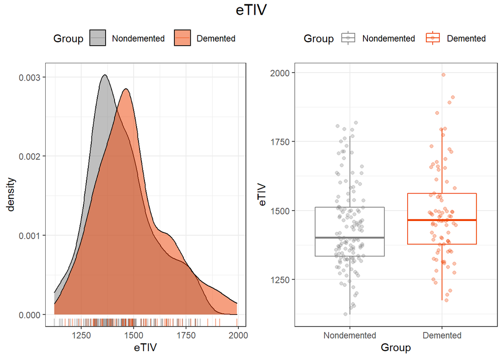

```r
p1 <- ggplot(data = oasis_cross_sectional_narm, aes(x = eTIV, fill = Group)) +
      geom_density(alpha = 0.5) +
      scale_fill_manual(values = c("gray50", "orangered2")) +
      geom_rug(aes(color = Group), alpha = 0.5) +
      scale_color_manual(values = c("gray50", "orangered2")) +
      theme_bw()
p2 <- ggplot(data = oasis_cross_sectional_narm, aes(x = Group, y = eTIV, color = Group)) +
      geom_boxplot(outlier.shape = NA) +
      geom_jitter(alpha = 0.3, width = 0.15) +
      scale_color_manual(values = c("gray50", "orangered2")) +
      theme_bw()
final_plot <- ggarrange(p1, p2, legend = "top")
final_plot <- annotate_figure(final_plot, top = text_grob("eTIV", size = 15))
final_plot
```

```r
#Calculamos la media y la mediana
tapply(oasis_cross_sectional_narm$eTIV, oasis_cross_sectional_narm$Group, mean)
```

```
## Nondemented    Demented
##    1439.444    1490.210
```

```r
tapply(oasis_cross_sectional_narm$eTIV, oasis_cross_sectional_narm$Group, median)
```

```
## Nondemented    Demented
##        1402        1465
```

En esta variable el grupo converted tiene una mediana significativamente más baja que las otras dos, en la media en cambio no hay tanta diferencia. La variable Nondemented tiene una media por encima de Demented, en cambio una mediana por debajo. En los datos seccionales no hay demasiada diferencia entre grupos.

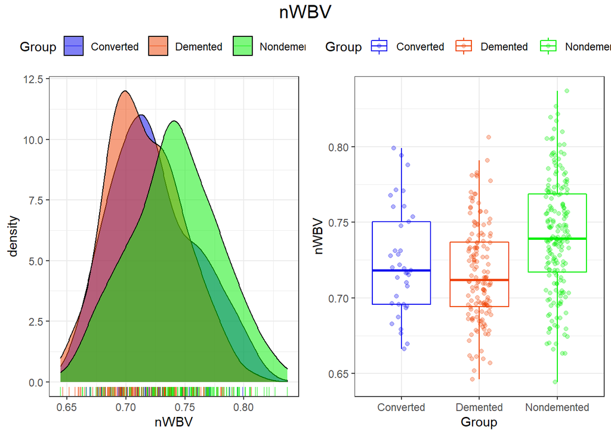

```r
#Volumen total normalizado
p1 <- ggplot(data = oasis_longitudinal, aes(x = nWBV, fill = Group)) +
      geom_density(alpha = 0.5) +
      scale_fill_manual(values = c("blue2", "orangered2", "green2")) +
      geom_rug(aes(color = Group), alpha = 0.5) +
      scale_color_manual(values = c("blue2", "orangered2", "green2")) +
      theme_bw()
p2 <- ggplot(data = oasis_longitudinal, aes(x = Group, y = nWBV, color = Group)) +
      geom_boxplot(outlier.shape = NA) +
      geom_jitter(alpha = 0.3, width = 0.15) +
      scale_color_manual(values = c("blue2", "orangered2", "green2")) +
      theme_bw()
final_plot <- ggarrange(p1, p2, legend = "top")
final_plot <- annotate_figure(final_plot, top = text_grob("nWBV", size = 15))
final_plot
```

```r
tapply(oasis_longitudinal$nWBV, oasis_longitudinal$Group, mean)
```

```
##   Converted    Demented Nondemented
##   0.7237336   0.7163034   0.7408726
```

```r
tapply(oasis_longitudinal$nWBV, oasis_longitudinal$Group, median)
```

```
##   Converted    Demented Nondemented
##   0.7180650   0.7118355   0.7392630
```

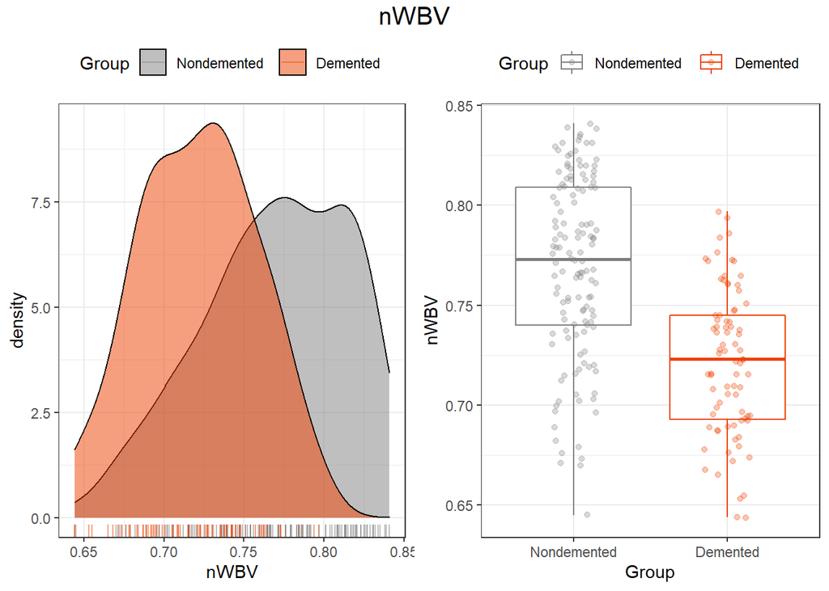

```r
p1 <- ggplot(data = oasis_cross_sectional_narm, aes(x = nWBV, fill = Group)) +
      geom_density(alpha = 0.5) +
      scale_fill_manual(values = c("gray50", "orangered2")) +
      geom_rug(aes(color = Group), alpha = 0.5) +
      scale_color_manual(values = c("gray50", "orangered2")) +
      theme_bw()
p2 <- ggplot(data = oasis_cross_sectional_narm, aes(x = Group, y = nWBV, color = Group)) +
      geom_boxplot(outlier.shape = NA) +
      geom_jitter(alpha = 0.3, width = 0.15) +
      scale_color_manual(values = c("gray50", "orangered2")) +
      theme_bw()
final_plot <- ggarrange(p1, p2, legend = "top")
final_plot <- annotate_figure(final_plot, top = text_grob("nWBV", size = 15))
final_plot
```

```r
#Calculamos la media y la mediana
tapply(oasis_cross_sectional_narm$nWBV, oasis_cross_sectional_narm$Group, mean)
```

```
## Nondemented    Demented
##   0.7691880   0.7214568
```

```r
tapply(oasis_cross_sectional_narm$nWBV, oasis_cross_sectional_narm$Group, median)
```

```
## Nondemented    Demented
##       0.773       0.723
```

En esta variabe sí se ven diferencias entre los grupos, los no dementes tienen valores en promedio más altos, que los dementes y los converted. En este caso la diferencia entre grupos es más significativa, en los datos seccionales.

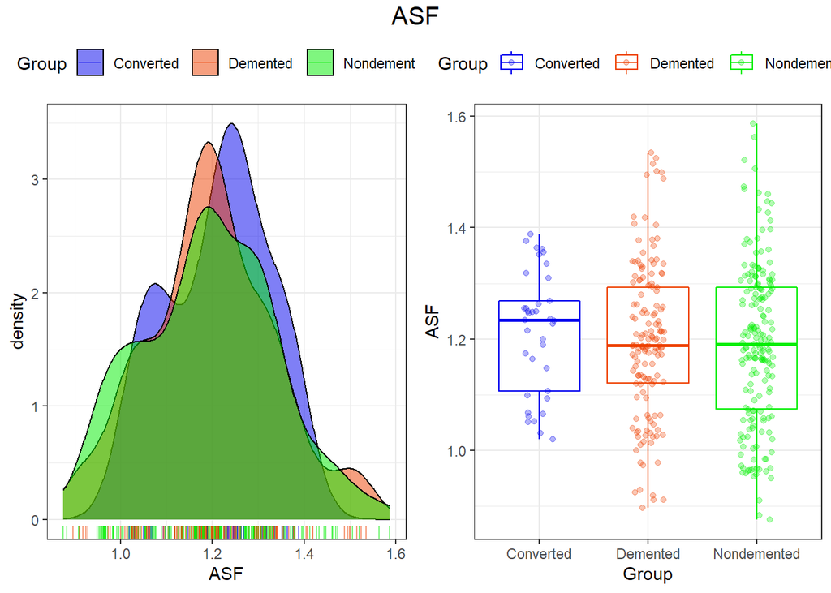

```r
#Atlas Scaling Factor
p1 <- ggplot(data = oasis_longitudinal, aes(x = ASF, fill = Group)) +
      geom_density(alpha = 0.5) +
      scale_fill_manual(values = c("blue2", "orangered2", "green2")) +
      geom_rug(aes(color = Group), alpha = 0.5) +
      scale_color_manual(values = c("blue2", "orangered2", "green2")) +
      theme_bw()
p2 <- ggplot(data = oasis_longitudinal, aes(x = Group, y = ASF, color = Group)) +
      geom_boxplot(outlier.shape = NA) +
      geom_jitter(alpha = 0.3, width = 0.15) +
      scale_color_manual(values = c("blue2", "orangered2", "green2")) +
      theme_bw()
final_plot <- ggarrange(p1, p2, legend = "top")
final_plot <- annotate_figure(final_plot, top = text_grob("ASF", size = 15))
final_plot
```

```r
tapply(oasis_longitudinal$ASF, oasis_longitudinal$Group, mean)
```

```
##   Converted    Demented Nondemented
##    1.212422    1.196880    1.191066
```

```r
tapply(oasis_longitudinal$ASF, oasis_longitudinal$Group, median)
```

```
##   Converted    Demented Nondemented
##    1.233637    1.188655    1.190225
```

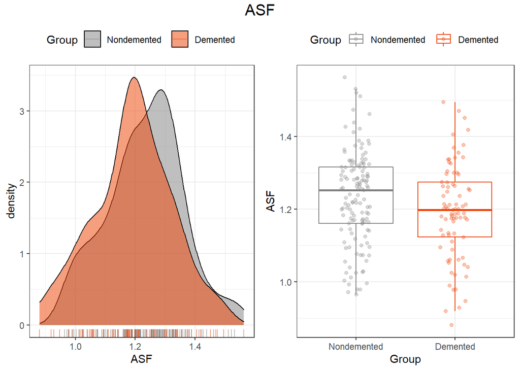

```r
p1 <- ggplot(data = oasis_cross_sectional_narm, aes(x = ASF, fill = Group)) +
      geom_density(alpha = 0.5) +
      scale_fill_manual(values = c("gray50", "orangered2")) +
      geom_rug(aes(color = Group), alpha = 0.5) +
      scale_color_manual(values = c("gray50", "orangered2")) +
      theme_bw()
p2 <- ggplot(data = oasis_cross_sectional_narm, aes(x = Group, y = ASF, color = Group)) +
      geom_boxplot(outlier.shape = NA) +
      geom_jitter(alpha = 0.3, width = 0.15) +
      scale_color_manual(values = c("gray50", "orangered2")) +
      theme_bw()
final_plot <- ggarrange(p1, p2, legend = "top")
final_plot <- annotate_figure(final_plot, top = text_grob("ASF", size = 15))
final_plot
```

```r
#Calculamos la media y la mediana
tapply(oasis_cross_sectional_narm$ASF, oasis_cross_sectional_narm$Group, mean)
```

```
## Nondemented    Demented
##    1.232474    1.192309
```

```r
tapply(oasis_cross_sectional_narm$ASF, oasis_cross_sectional_narm$Group, median)
```

```
## Nondemented    Demented
##       1.252       1.198
```

En este caso no parece haber diferencias en la distribución.

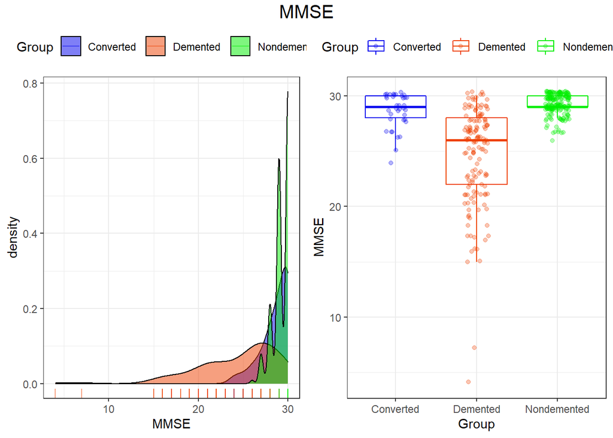

```r
#MMSE (Test de deterioro cognitivo)

p1 <- ggplot(data = oasis_longitudinal, aes(x = MMSE, fill = Group)) +
      geom_density(alpha = 0.5) +
      scale_fill_manual(values = c("blue2", "orangered2", "green2")) +
      geom_rug(aes(color = Group), alpha = 0.5) +
      scale_color_manual(values = c("blue2", "orangered2", "green2")) +
      theme_bw()
p2 <- ggplot(data = oasis_longitudinal, aes(x = Group, y = MMSE, color = Group)) +
      geom_boxplot(outlier.shape = NA) +
      geom_jitter(alpha = 0.3, width = 0.15) +
      scale_color_manual(values = c("blue2", "orangered2", "green2")) +
      theme_bw()
final_plot <- ggarrange(p1, p2, legend = "top")
final_plot <- annotate_figure(final_plot, top = text_grob("MMSE", size = 15))
final_plot
```

```r
tapply(oasis_longitudinal$MMSE, oasis_longitudinal$Group, na.rm= TRUE, mean)
```

```
##   Converted    Demented Nondemented
##    28.67568    24.51389    29.22632
```

```r
tapply(oasis_longitudinal$MMSE, oasis_longitudinal$Group, na.rm= TRUE, median)
```

```
##   Converted    Demented Nondemented
##          29          26          29
```

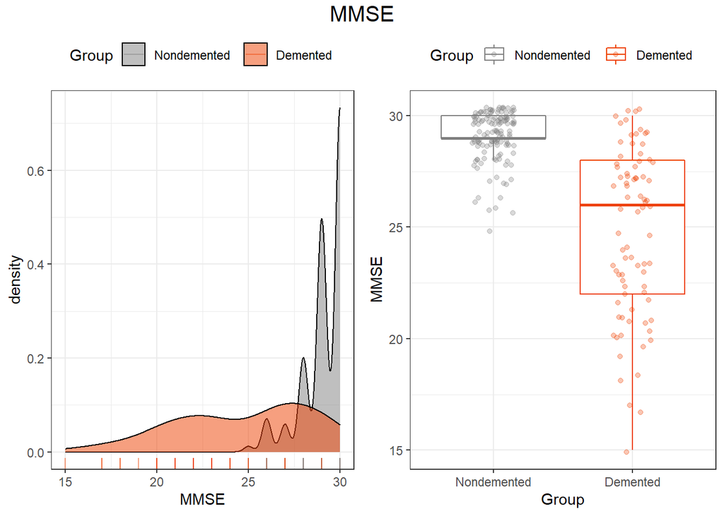

```r
p1 <- ggplot(data = oasis_cross_sectional_narm, aes(x = MMSE, fill = Group)) +
      geom_density(alpha = 0.5) +
      scale_fill_manual(values = c("gray50", "orangered2")) +
      geom_rug(aes(color = Group), alpha = 0.5) +
      scale_color_manual(values = c("gray50", "orangered2")) +
      theme_bw()
p2 <- ggplot(data = oasis_cross_sectional_narm, aes(x = Group, y = MMSE, color = Group)) +
      geom_boxplot(outlier.shape = NA) +
      geom_jitter(alpha = 0.3, width = 0.15) +
      scale_color_manual(values = c("gray50", "orangered2")) +
      theme_bw()
final_plot <- ggarrange(p1, p2, legend = "top")
final_plot <- annotate_figure(final_plot, top = text_grob("MMSE", size = 15))
final_plot
```

```r
#Calculamos la media y la mediana
tapply(oasis_cross_sectional_narm$MMSE, oasis_cross_sectional_narm$Group, mean)
```

```
## Nondemented    Demented
##    29.09774    24.71605
```

```r
tapply(oasis_cross_sectional_narm$MMSE, oasis_cross_sectional_narm$Group, median)
```

```
## Nondemented    Demented
##          29          26
```

En este caso se ven diferencias entre los que tienen demencia y los otros dos grupos, pero no entre converted y nondemented. En el caso de los datos seccionales hay una diferencia significativa entre los grupos.

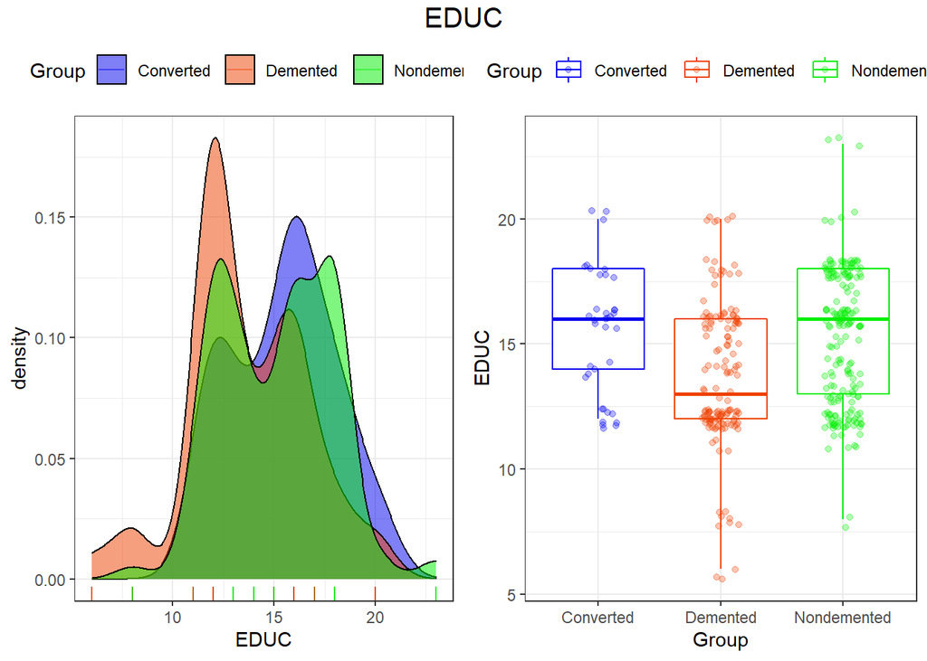

```r
#Nivel de estudios
p1 <- ggplot(data = oasis_longitudinal, aes(x = EDUC, fill = Group)) +
      geom_density(alpha = 0.5) +
      scale_fill_manual(values = c("blue2", "orangered2", "green2")) +
      geom_rug(aes(color = Group), alpha = 0.5) +
      scale_color_manual(values = c("blue2", "orangered2", "green2")) +
      theme_bw()
p2 <- ggplot(data = oasis_longitudinal, aes(x = Group, y = EDUC, color = Group)) +
      geom_boxplot(outlier.shape = NA) +
      geom_jitter(alpha = 0.3, width = 0.15) +
      scale_color_manual(values = c("blue2", "orangered2", "green2")) +
      theme_bw()
final_plot <- ggarrange(p1, p2, legend = "top")
final_plot <- annotate_figure(final_plot, top = text_grob("EDUC", size = 15))
final_plot
```

```r
tapply(oasis_longitudinal$EDUC, oasis_longitudinal$Group, na.rm= TRUE, mean)
```

```
##   Converted    Demented Nondemented
##    15.45946    13.67123    15.14211
```

```r
tapply(oasis_longitudinal$EDUC, oasis_longitudinal$Group, na.rm= TRUE, median)
```

```
##   Converted    Demented Nondemented
##          16          13          16
```

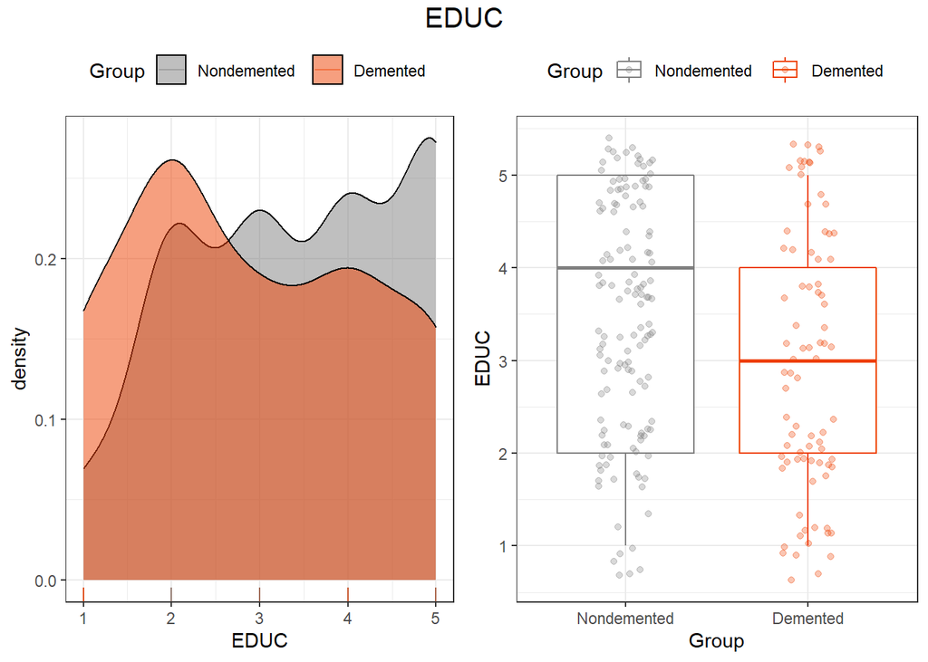

```r
oasis_cross_sectional_narm$EDUC=oasis_cross_sectional_narm$Educ
p1 <- ggplot(data = oasis_cross_sectional_narm, aes(x = EDUC, fill = Group)) +
      geom_density(alpha = 0.5) +
      scale_fill_manual(values = c("gray50", "orangered2")) +
      geom_rug(aes(color = Group), alpha = 0.5) +
      scale_color_manual(values = c("gray50", "orangered2")) +
      theme_bw()
p2 <- ggplot(data = oasis_cross_sectional_narm, aes(x = Group, y = EDUC, color = Group)) +
      geom_boxplot(outlier.shape = NA) +
      geom_jitter(alpha = 0.3, width = 0.15) +
      scale_color_manual(values = c("gray50", "orangered2")) +
      theme_bw()
final_plot <- ggarrange(p1, p2, legend = "top")
final_plot <- annotate_figure(final_plot, top = text_grob("EDUC", size = 15))
final_plot
```

```r
#Calculamos la media y la mediana
tapply(oasis_cross_sectional_narm$EDUC, oasis_cross_sectional_narm$Group, mean)
```

```
## Nondemented    Demented
##    3.443609    2.913580
```

```r
tapply(oasis_cross_sectional_narm$EDUC, oasis_cross_sectional_narm$Group, median)
```

```
## Nondemented    Demented
##           4           3
```

En esta variable también se ven diferencias entre los sujetos con demencia y los otros dos grupos. En el caso de los datos seccionales también se ven diferencias.

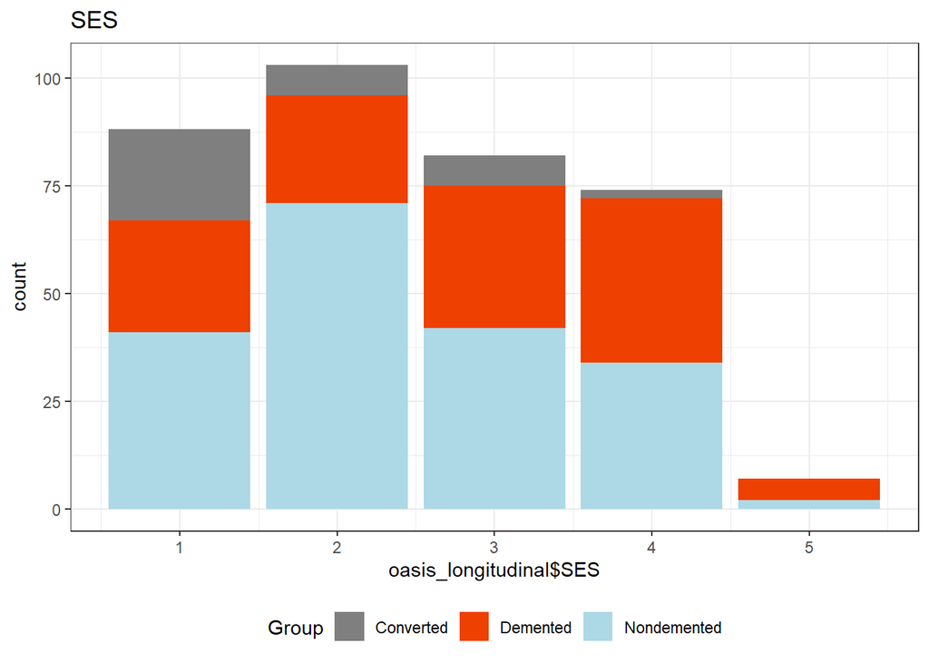

```r
#Status socioeconómico
ggplot(data = oasis_longitudinal, aes(x = oasis_longitudinal$SES, y = ..count.., fill = Group)) +
  geom_bar() +
  labs(title = "SES") +
  scale_fill_manual(values = c("gray50", "orangered2", "lightblue")) +
  theme_bw() +
  theme(legend.position = "bottom")
```

```r
round(prop.table(table(oasis_longitudinal$SES, oasis_longitudinal$Group)),2)
```

```
##
##     Converted Demented Nondemented
##   1      0.06     0.07        0.12
##   2      0.02     0.07        0.20
##   3      0.02     0.09        0.12
##   4      0.01     0.11        0.10
##   5      0.00     0.01        0.01
```

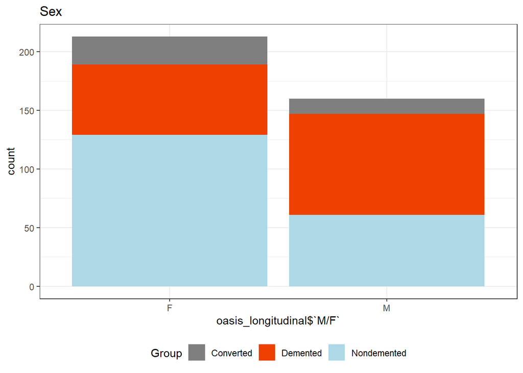

```r
#Sexo
ggplot(data = oasis_longitudinal, aes(x = oasis_longitudinal$`M/F`, y = ..count.., fill = Group)) +
  geom_bar() +
  labs(title = "Sex") +
  scale_fill_manual(values = c("gray50", "orangered2", "lightblue")) +
  theme_bw() +
  theme(legend.position = "bottom")
```

```r
round(prop.table(table(oasis_longitudinal$`M/F`, oasis_longitudinal$Group)),2)
```

```
##
##     Converted Demented Nondemented
##   F      0.06     0.16        0.35
##   M      0.03     0.23        0.16
```

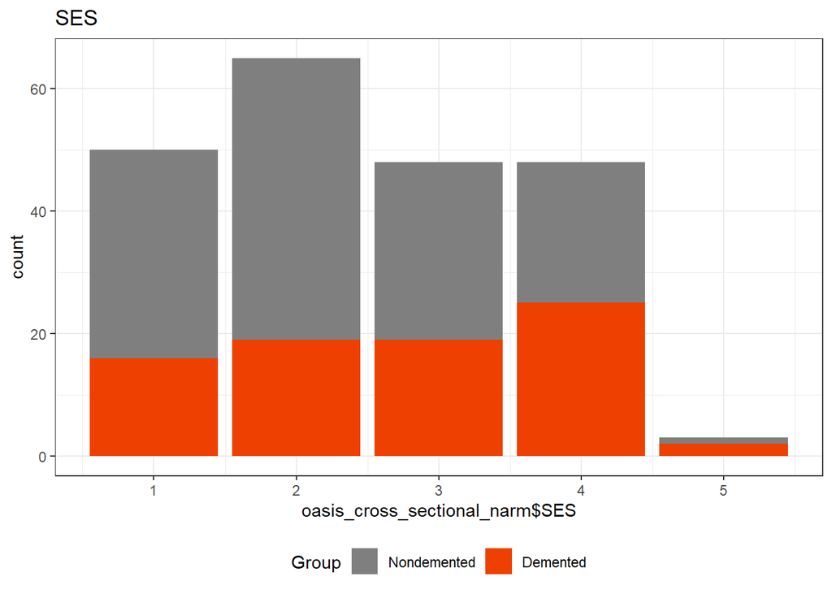

```r
#Status socioeconómico
ggplot(data = oasis_cross_sectional_narm, aes(x = oasis_cross_sectional_narm$SES, y = ..count.., fill = Group)) +
  geom_bar() +
  labs(title = "SES") +
  scale_fill_manual(values = c("gray50", "orangered2")) +
  theme_bw() +
  theme(legend.position = "bottom")
```

```r
round(prop.table(table(oasis_cross_sectional_narm$SES, oasis_cross_sectional_narm$Group)),2)
```

```
##
##     Nondemented Demented
##   1        0.16     0.07
##   2        0.21     0.09
##   3        0.14     0.09
##   4        0.11     0.12
##   5        0.00     0.01
```

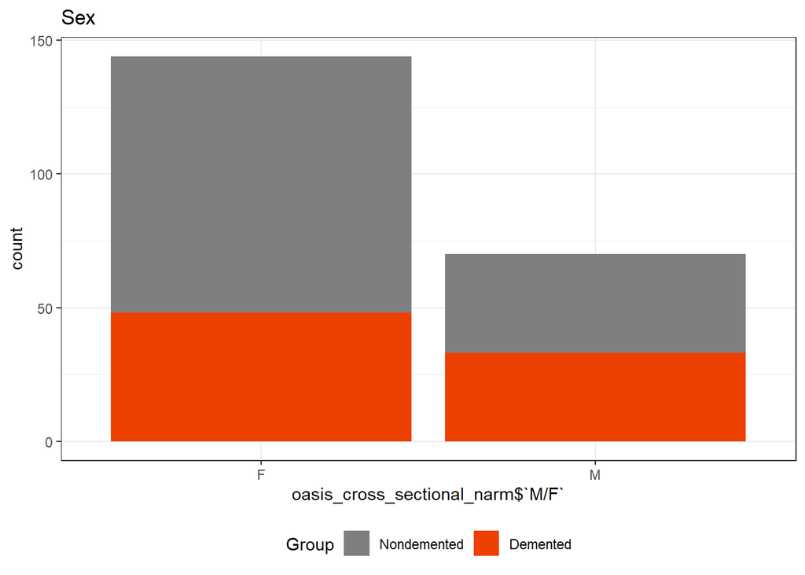

```r
#Sexo
oasis_cross_sectional_narm$`M/F`=oasis_cross_sectional_narm$M.F
ggplot(data = oasis_cross_sectional_narm, aes(x = oasis_cross_sectional_narm$`M/F`, y = ..count.., fill = Group)) +
  geom_bar() +
  labs(title = "Sex") +
  scale_fill_manual(values = c("gray50", "orangered2", "lightblue")) +
  theme_bw() +
  theme(legend.position = "bottom")
```

```r
round(prop.table(table(oasis_cross_sectional_narm$`M/F`, oasis_cross_sectional_narm$Group)),2)
```

```
##
##     Nondemented Demented
##   F        0.45     0.22
##   M        0.17     0.15
```

## Random forest

Para terminar el apartado del análisis exploratorio, y complementar el último punto, vamos a realizar un análisis random forest con el que descubriremos que variables predicen mejor la variable respuesta:

```r
library(randomForest)
library(tidyverse)
```

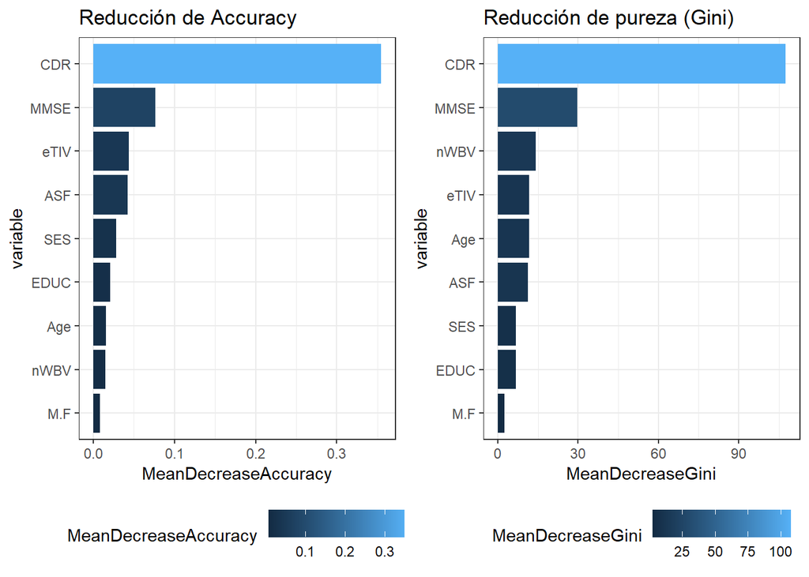

```r
#Seleccionamos las variables y generamos el análisis random forest
datos_rf <- oasis_longitudinal %>%
            select(-`Subject ID`, -`MRI ID`, -`MR Delay`, -Visit, -Hand) %>% na.omit()
datos_rf <- map_if(.x = datos_rf, .p = is.character, .f = as.factor) %>% as.data.frame()
modelo_randforest <- randomForest(formula = Group ~ . ,
                                  data = na.omit(datos_rf),
                                  mtry = 5,
                                  importance = TRUE,
                                  ntree = 1000)
importancia <- as.data.frame(modelo_randforest$importance)
importancia <- rownames_to_column(importancia,var = "variable")

p1 <- ggplot(data = importancia, aes(x = reorder(variable, MeanDecreaseAccuracy),
                               y = MeanDecreaseAccuracy,
                               fill = MeanDecreaseAccuracy)) +
      labs(x = "variable", title = "Reducción de Accuracy") +
      geom_col() +
      coord_flip() +
      theme_bw() +
      theme(legend.position = "bottom")

p2 <- ggplot(data = importancia, aes(x = reorder(variable, MeanDecreaseGini),
                               y = MeanDecreaseGini,
                               fill = MeanDecreaseGini)) +
      labs(x = "variable", title = "Reducción de pureza (Gini)") +
      geom_col() +
      coord_flip() +
      theme_bw() +
      theme(legend.position = "bottom")
ggarrange(p1, p2)
```

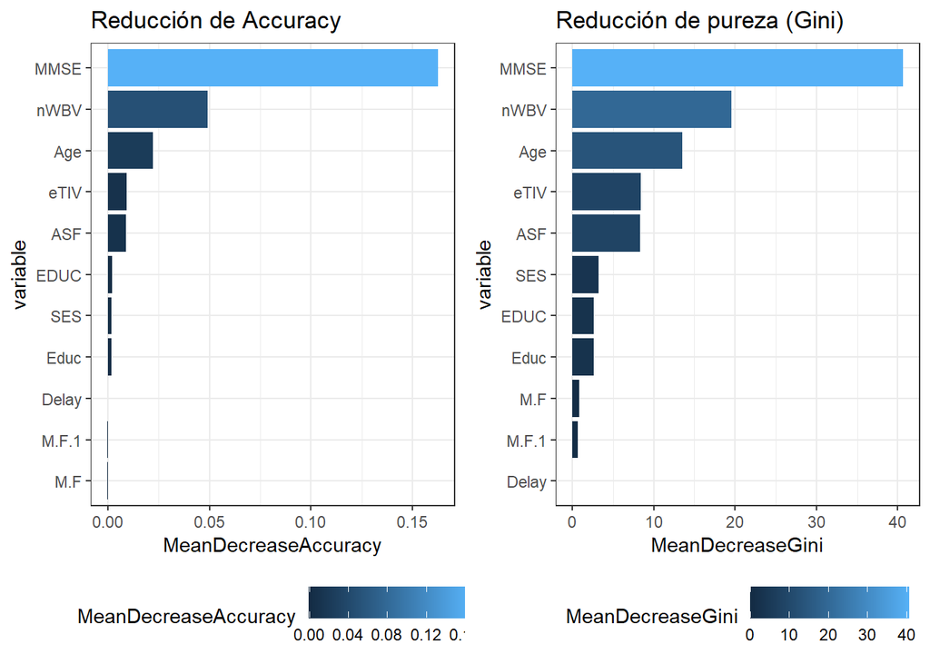

```r
datos_rf <- oasis_cross_sectional_narm %>%
            select(-ID, -Hand, -CDR) %>% na.omit()
datos_rf <- map_if(.x = datos_rf, .p = is.character, .f = as.factor) %>% as.data.frame()
modelo_randforest <- randomForest(formula = Group ~ . ,
                                  data = na.omit(datos_rf),
                                  mtry = 5,
                                  importance = TRUE,
                                  ntree = 1000)
importancia <- as.data.frame(modelo_randforest$importance)
importancia <- rownames_to_column(importancia,var = "variable")

p1 <- ggplot(data = importancia, aes(x = reorder(variable, MeanDecreaseAccuracy),
                               y = MeanDecreaseAccuracy,
                               fill = MeanDecreaseAccuracy)) +
      labs(x = "variable", title = "Reducción de Accuracy") +
      geom_col() +
      coord_flip() +
      theme_bw() +
      theme(legend.position = "bottom")

p2 <- ggplot(data = importancia, aes(x = reorder(variable, MeanDecreaseGini),
                               y = MeanDecreaseGini,
                               fill = MeanDecreaseGini)) +
      labs(x = "variable", title = "Reducción de pureza (Gini)") +
      geom_col() +
      coord_flip() +
      theme_bw() +
      theme(legend.position = "bottom")
ggarrange(p1, p2)
```

Este análisis apunta a que las mejores variables para predecir la demencia son las CDR y MMSE.

# Preprocesamiento

## Tratamiento de los valores ausentes

Como vimos en la exploración de los datos hay valores ausentes, rincipalmente concentrados en las variables SES, EDUC y MMSE. Antes de seguir habría que eliminarlos ya que hay algoritmos de ML que no admiten estos valores. Tenemos dos opciones, eliminar las variables con valores ausentes o eliminar las observaciones con valores ausentes. Otra opción sería realizar una imputación para no perder la información de esas variables u observaciones, imputar sería estimar los valores que faltan por medio de la información que sí tenemos.

```r
#Si eliminamos las observaciones se nos quedaría:
nrow(na.omit(oasis_cross_sectional))
```

```
## [1] 216
```

```r
nrow(na.omit(oasis_longitudinal))
```

```
## [1] 354
```

```r
oasis_longitudinal_narm=na.omit(oasis_longitudinal)

#Imputación
library(recipes)
objeto_recipe <- recipe(formula = Group ~ Age + `M/F` + EDUC + SES +
                                  MMSE + CDR + eTIV + nWBV + ASF,
                        data =  oasis_longitudinal)
objeto_recipe
```

```
## Data Recipe
##
## Inputs:
##
##       role #variables
##    outcome          1
##  predictor          9
```

```r
objeto_recipe <- objeto_recipe %>% step_bagimpute(SES)
objeto_recipe
```

```
## Data Recipe
##
## Inputs:
##
##       role #variables
##    outcome          1
##  predictor          9
##
## Operations:
##
## Bagged tree imputation for SES
```

## Variables con varianza cercana 0

Otra parte importante del preprocesado será eliminar variables que no aporten nada, como vimos la variable Hand no se utilizará ya que no tiene diferentes niveles, pero además hay una forma de ser si las variables pueden no aortar información y es viendo si su varianza es igual o cercana a 0. Con la función `nearZeroVars`, podemos averiguar si alguna función tiene varianza cercana a 0.

```r
library(caret)
oasis_longitudinal %>% select(Age, `M/F`, EDUC, SES, MMSE, CDR, eTIV, nWBV, ASF) %>% nearZeroVar(saveMetrics = TRUE)
```

|  | freqRatio | percentUnique | zeroVar | nzv |
| --- | --- | --- | --- | --- |
| Age | 1.181818 | 10.455764 | FALSE | FALSE |
| M/F | 1.331250 | 0.536193 | FALSE | FALSE |
| EDUC | 1.271605 | 3.217158 | FALSE | FALSE |
| SES | 1.170455 | 1.340483 | FALSE | FALSE |
| MMSE | 1.252747 | 4.825737 | FALSE | FALSE |
| CDR | 1.674797 | 1.072386 | FALSE | FALSE |
| eTIV | 1.000000 | 99.463807 | FALSE | FALSE |
| nWBV | 1.000000 | 100.000000 | FALSE | FALSE |
| ASF | 1.000000 | 99.463807 | FALSE | FALSE |

Entre los predictores incluidos en el modelo, no se detecta ninguno con varianza cero o próxima a cero.

## Normalización

La normalización es un paso importante para ajustar el modelo, hay diferenctes tipos de normalización vamos a implementar dos tipos y comporbaremos cual de ellas se puede ajustar mejor.

```r
#Primero eliminamos la variable converted del conjunto de datos que no utilizaremos.
oasis_longitudinal_narm_2=filter(oasis_longitudinal_narm, Group != "Converted")

#Normalización estándar
normalize <- function(x) {
  return ((x - min(x)) / (max(x) - min(x)))
  }

oasis_longitudinal_n <- as.data.frame(lapply(oasis_longitudinal_narm_2[8:15], normalize))

#Cambiamos el nombre de la varible educ para que esté igual en ambos conjuntos de datos
require(reshape)
oasis_longitudinal_n = rename(oasis_longitudinal_n, c(EDUC="Educ"))

#Tras normalizarlo añadimos la variable sexo al conjunto
oasis_longitudinal_n2=cbind(oasis_longitudinal_narm_2$`M/F`, oasis_longitudinal_n)

#Camiamos el nombre de esta variable a Sex
oasis_longitudinal_n3 = rename(oasis_longitudinal_n2, c("oasis_longitudinal_narm_2$`M/F`"="Sex"))
names(oasis_longitudinal_n3)
```

```
## [1] "Sex"  "Age"  "Educ" "SES"  "MMSE" "CDR"  "eTIV" "nWBV" "ASF"
```

```r
#Hacemos lo mismo en los datos seccionales
oasis_cross_sectional_n=as.data.frame(lapply(oasis_cross_sectional_narm[4:11], normalize))

oasis_cross_sectional_n2=cbind(oasis_cross_sectional_narm$M.F, oasis_cross_sectional_n)

oasis_cross_sectional_n3 = rename(oasis_cross_sectional_n2, c(`oasis_cross_sectional_narm$M.F`="Sex"))
names(oasis_cross_sectional_n3)
```

```
## [1] "Sex"  "Age"  "Educ" "SES"  "MMSE" "CDR"  "eTIV" "nWBV" "ASF"
```

```r
#Estandarización por puntuación Z
oasis_longitudinal_z <- as.data.frame(scale(oasis_longitudinal_narm[8:15]))

oasis_seccional_z <- as.data.frame(scale(oasis_cross_sectional_narm[4:11]))

#Borramos la variable CDR
oasis_longitudinal_n4=select(oasis_longitudinal_n3, -CDR)
oasis_cross_sectional_n4=select(oasis_cross_sectional_n3, -CDR)

#Creamos una variable con los labels de los dos conjuntos
labels_longitudinal=oasis_longitudinal_narm_2$Group
labels_seccional=oasis_cross_sectional_narm$Group

str(oasis_cross_sectional_n4)
```

```
## 'data.frame':    214 obs. of  8 variables:
##  $ Sex : chr  "F" "F" "F" "M" ...
##  $ Age : num  0.651 0.349 0.635 0.651 0.302 ...
##  $ Educ: num  0.25 0.75 0.75 1 0.5 1 0.25 0.5 1 1 ...
##  $ SES : num  0.5 0 0.5 0.25 0.25 0.25 0.75 0.75 0 0.25 ...
##  $ MMSE: num  0.933 0.933 0.8 1 1 ...
##  $ eTIV: num  0.2543 0.0276 0.3809 0.5903 0.2278 ...
##  $ nWBV: num  0.503 0.843 0.325 0.228 0.929 ...
##  $ ASF : num  0.623 0.953 0.478 0.282 0.657 ...
```

```r
str(oasis_longitudinal_n4)
```

```
## 'data.frame':    317 obs. of  8 variables:
##  $ Sex : chr  "M" "M" "F" "F" ...
##  $ Age : num  0.711 0.737 0.737 0.789 0.526 ...
##  $ Educ: num  0.471 0.471 0.706 0.706 0.353 ...
##  $ SES : num  0.25 0.25 0.5 0.5 0.75 0.75 0.75 0.25 0.25 0.25 ...
##  $ MMSE: num  0.885 1 0.923 0.885 0.923 ...
##  $ eTIV: num  0.98 1 0.122 0.105 0.649 ...
##  $ nWBV: num  0.269 0.191 0.338 0.384 0.349 ...
##  $ ASF : num  0.0111 0 0.7988 0.8245 0.2301 ...
```

```r
str(labels_seccional)
```

```
##  Factor w/ 2 levels "Nondemented",..: 1 1 2 1 1 1 2 1 1 1 ...
```

```r
str(labels_longitudinal)
```

```
##  chr [1:317] "Nondemented" "Nondemented" "Nondemented" "Nondemented" ...
```